# PanTedeuszRymy

Analiza rymów w Panu Tadeuszu - Jakub Wysocki (319126), Sebastian Sikorski (319096)

Podstawy Reprezentacji i Analizy Danych 2022Z Prowadzący: prof. Marcin Iwanowski

Projekt ma na celu analizę Pana tadeusza pod względem rymów Pierwszym krokiem jest wczytanie pliku tekstowego z treścią poematu "Pan Tadeusz", źródło to https://wolnelektury.pl/media/book/txt/pan-tadeusz.txt. Potem następuje tokenizacja tekst tak byśmy mogli odczytać ostatnie słowo każdego wersu.

```python
import numpy as np
import pandas as pd
import seaborn as sns
import matplotlib.pyplot as plt
# zmiana sposobu wyświetlania danych typu float
pd.options.display.float_format = "{:.3f}".format
pantadeusz = []
ograniczniki = ["\\n", "'"]
with open('dane/pan Tadeusz.txt', encoding='utf-8') as f:
    for line in f:
        linijka = repr(line)
        for znak in ograniczniki:
            linijka = linijka.replace(znak,"")
        if not(linijka == ""):
            pantadeusz.append(linijka)
ksiegi = []
for linijka in pantadeusz:
    slowa_linijki = linijka.split()
    if (len(slowa_linijki)==2): # dwuwyrazowe linijki
        if (slowa_linijki[0] == 'Księga'): # pierwszy wyraz powinien brzmieć 'księga'
            ksiegi.append(slowa_linijki[1])


# Tokenizacja
PanTadeusz = []
niepotrzebne_znaki = ["!",",", ".","    ",":",";","?","(",")","— ","*","»","…","«","—","-","/"]
rodzaj_tekstu = "inny"
mamKsiege = False
mamTytul = False
tekstKsiegi = False
for linijka in pantadeusz:
    if rodzaj_tekstu == "streszczenie":
        rodzaj_tekstu = "tresc"
    elif rodzaj_tekstu == "tytul":
        rodzaj_tekstu = "streszczenie"
        ksiega["streszczenie"] = linijka
    elif rodzaj_tekstu == "naglowek":
        rodzaj_tekstu = "tytul"
        ksiega["tytul"] = linijka
    slowa_linijki = linijka.split()
    if (len(slowa_linijki) in [1,2]):
        if slowa_linijki[0] == 'Księga':
            if rodzaj_tekstu == "tresc":
                ksiega["wersy"] = tresc
                PanTadeusz.append(ksiega) # zapisz poprzednią księgę
            rodzaj_tekstu = "naglowek"
            tresc = []
            ksiega = {"numer":slowa_linijki[1],
                      "tytul":"",
                      "streszczenie":"",
                      "wersy":[]}
        elif slowa_linijki[0] == 'Epilog':
            ksiega["wersy"] = tresc
            PanTadeusz.append(ksiega) # zapisz dwunastą księgę
            rodzaj_tekstu = "streszczenie"
            tresc = []
            ksiega = {"numer":"epilog",
                      "tytul":"Epilog",
                      "streszczenie":"",
                      "wersy":[]}
        elif slowa_linijki[0] == '-----':
            ksiega["wersy"] = tresc
            PanTadeusz.append(ksiega) # zapisz epilog
            rodzaj_tekstu = "inne"
    if rodzaj_tekstu == "tresc":
        for znak in niepotrzebne_znaki:
            linijka = linijka.replace(znak,"").lower()
        tresc.append(linijka.split())
```

Definiowanie niezbędnych funkcji

```python
# rozkładanie słowa na sylaby, każda sylaba musi mieć w sobie samogłoskę,
# co jest elementem decydującym w funkcji
def ilosc_sylab_w_slowie(str):
    samogloski = ["ę","e","é","y","u","i","a","ą","o","ó"]
    sam = False
    syl = 0
    for i in range(0,len(str)):
        if sam:
            if str[i] in samogloski:
                pass
            else:
                sam = False
        else:
            if str[i] in samogloski:
                syl += 1
                sam = True
    return syl

# analogicznie liczymy sylaby w końcówce słowa
def ilosc_sylab_w_koncowce(str):
    samogloski = ["ę","e","é","y","u","i","a","ą","o","ó"]
    sam = False
    sol = True
    syl = 0
    for i in range(0,len(str)):
        if sam:
            if str[i] in samogloski:
                pass
            else:
                sam = False
                sol = False
        else:
            if str[i] in samogloski:
                syl += 1
                sam = True
            else:
                sol = False
    if sol:
        return 0
    return syl

# funkcja zwracająca wspólną końcówkę dwóch słów
def rymy_koncowe(str1, str2):
    i1 = len(str1) - 1
    i2 = len(str2) - 1
    i1m = i1
    i2m = i2
    flag = True
    while(i1 > -1 and i2 > -1):
        if str1[i1] != str2[i2]:
            flag = True
            for x in litery:
                wynik = x(str1,str2,i1,i2,i1m,i2m)
                if wynik[0]:
                    flag = False
                    i1 -= wynik[1]
                    i2 -= wynik[2]
                    break
            if flag:
                break
        i1 -= 1
        i2 -= 1
    if i1 == len(str1) - 1 or i2 == len(str2) - 1:
        return("","")
    return(str1[i1+1:], str2[i2+1:])

# funkcja sprawdzająca, czy sylaby się rymują
def rymuje_sie(koncowki):
    s1 = ilosc_sylab_w_koncowce(koncowki[0])
    if  s1 < 1:
        return False
    s2 = ilosc_sylab_w_koncowce(koncowki[1])
    if s1 == s2 or (s1 >1 and s2 >1):
        return True
    return False

# funkcja zwracająca długość wspólnej końcówki dwóch słów
def dlugosc(str1, str2):
    return len(rymy_koncowe(str1, str2)[0])

# rozkład rymów na monorymy, rymy krzywe, okalające i na wyrazy nie rymujące się
def okresl_rymy(PanT,OkW):
    zbr = []
    for ksiega in PanT:
        zbr.append({"monorymy" : {2:[], 3:[], 4:[]}, "krzywe" : [], "okalajance" : [], "inne" : []})
    for i in range(0,len(PanT)):
        lista_wersow = PanTadeusz[i]["wersy"]
        stan = 0
        drugi = lista_wersow[0][-1]
        czwarty = drugi
        trzeci = drugi
        koncowki = ()
        kolor = 1
        for wers_i in range(1,len(lista_wersow )):
            pierwszy = lista_wersow[wers_i][-1]
            #print(pierwszy+" "+drugi+" "+trzeci+" "+czwarty+" "+str(stan)+" "+str(wers_i))
            if stan == 0:
                koncowki = rymy_koncowe(pierwszy,drugi)
                if rymuje_sie(koncowki):
                    stan = 5
                else:
                    stan = 1
            elif stan == -1:
                stan = 0
            elif stan == 1:
                if rymuje_sie(rymy_koncowe(pierwszy,trzeci)):
                    stan = 2
                elif rymuje_sie(rymy_koncowe(drugi,pierwszy)):
                    stan = 3
                else:
                    stan = 0
                    if rymuje_sie(rymy_koncowe(trzeci,drugi)):
                        OkW[i][wers_i - 2]["kolor"] = kolor
                        OkW[i][wers_i - 2]["typ"] = "P"
                        OkW[i][wers_i - 1]["kolor"] = kolor
                        OkW[i][wers_i - 1]["typ"] = "P"
                        kolor += 1
                        zbr[i]["monorymy"][2].append(rymy_koncowe(trzeci,drugi))
                    else:
                        OkW[i][wers_i - 2]["kolor"] = 0
                        OkW[i][wers_i - 2]["typ"] = "I"
                        OkW[i][wers_i - 1]["kolor"] = 0
                        OkW[i][wers_i - 1]["typ"] = "I"
                        zbr[i]["inne"].append(trzeci + " " + drugi)
            elif stan == 2:
                if rymuje_sie(rymy_koncowe(pierwszy,trzeci)):
                    zbr[i]["krzywe"].append( pierwszy+" "+drugi + " " +drugi+" "+czwarty)
                    koncowki = rymy_koncowe(pierwszy,trzeci)
                    OkW[i][wers_i]["kolor"] = kolor
                    OkW[i][wers_i]["typ"] = "K"
                    OkW[i][wers_i]["ile"] = len(koncowki[0])
                    OkW[i][wers_i - 2]["kolor"] = kolor + 1
                    OkW[i][wers_i - 2]["typ"] = "K"
                    OkW[i][wers_i - 2]["ile"] = len(koncowki[1])
                    koncowki = rymy_koncowe(drugi,czwarty)
                    OkW[i][wers_i - 3]["kolor"] = kolor
                    OkW[i][wers_i - 3]["typ"] = "K"
                    OkW[i][wers_i - 3]["ile"] = len(koncowki[1])
                    OkW[i][wers_i - 1]["kolor"] = kolor + 1
                    OkW[i][wers_i - 1]["typ"] = "K"
                    OkW[i][wers_i - 1]["ile"] = len(koncowki[0])
                    stan = -1
                else:
                    zbr[i]["inne"].append(drugi + " " + trzeci + " " + czwarty)
                    stan = 0
            elif stan == 3:
                if rymuje_sie(rymy_koncowe(pierwszy,czwarty)):
                    zbr[i]["okalajance"].append(pierwszy+" "+drugi + " " + trzeci+" "+czwarty)
                    koncowki = rymy_koncowe(pierwszy,czwarty)
                    OkW[i][wers_i - 3]["kolor"] = kolor
                    OkW[i][wers_i - 3]["typ"] = "O"
                    OkW[i][wers_i - 3]["ile"] = len(koncowki[1])
                    OkW[i][wers_i]["kolor"] = kolor
                    OkW[i][wers_i]["typ"] = "O"
                    OkW[i][wers_i]["ile"] = len(koncowki[0])
                    koncowki = rymy_koncowe(drugi,trzeci)
                    OkW[i][wers_i - 2]["kolor"] = kolor + 1
                    OkW[i][wers_i - 2]["typ"] = "O"
                    OkW[i][wers_i - 2]["ile"] = len(koncowki[1])
                    OkW[i][wers_i - 1]["kolor"] = kolor + 1
                    OkW[i][wers_i - 1]["typ"] = "O"
                    OkW[i][wers_i - 1]["ile"] = len(koncowki[0])
                    kolor += 2
                    stan = -1
```

```python
                else:
                    zbr[i]["monorymy"][2].append(rymy_koncowe(drugi,trzeci))
                    OkW[i][wers_i - 2]["kolor"] = kolor
                    OkW[i][wers_i - 2]["typ"] = "P"
                    OkW[i][wers_i - 1]["kolor"] = kolor
                    OkW[i][wers_i - 1]["typ"] = "P"
                    kolor += 1
                    zbr[i]["inne"].append(czwarty)
                    stan = 0
            elif stan > 4:
                if rymuje_sie((rymy_koncowe(pierwszy,drugi)[1],koncowki[1])):
                    stan += 1
                else:
                    if stan > 5:
                        if ilosc_sylab_w_koncowce(rymy_koncowe(pierwszy,drugi)[0]) > ilosc_sylab_w_koncowce(koncowki[0]):
                            zbr[i]["monorymy"][stan - 4].append(koncowki)
                            stan = -5
                            koncowki = rymy_koncowe(pierwszy,drugi)
                        else:
                            for ik in range(stan-3):
                                OkW[i][wers_i - 1 - ik]["kolor"] = kolor
                                OkW[i][wers_i - 1 - ik]["typ"] = "M"
                                OkW[i][wers_i - 1 - ik]["ile"] = len(koncowki[0])
                            kolor += 1
                            zbr[i]["monorymy"][stan - 3].append((drugi,trzeci,czwarty))
                    else:
                        OkW[i][wers_i - 2]["kolor"] = kolor
                        OkW[i][wers_i - 2]["typ"] = "P"
                        OkW[i][wers_i - 2]["ile"] = len(koncowki[0])
                        OkW[i][wers_i - 1]["kolor"] = kolor
                        OkW[i][wers_i - 1]["typ"] = "P"
                        OkW[i][wers_i - 1]["ile"] = len(koncowki[1])
                        kolor += 1
                        zbr[i]["monorymy"][2].append(koncowki)
                    if stan== -5:
                        stan = 5
                    else:
                        stan = 0
            czwarty = trzeci
            trzeci = drugi
            drugi = pierwszy
        if stan == 0:
            zbr[i]["inne"].append(pierwszy)
        elif stan == 1:
            zbr[i]["inne"].append(trzeci + " " + pierwszy)
        elif stan == 2:
            zbr[i]["inne"].append(trzeci + " " + czwarty + " " + pierwszy)
        elif stan == 3:
            zbr[i]["inne"].append(trzeci + " " + czwarty + " " + pierwszy)
        elif stan > 4:
            if stan > 5:
                zbr[i]["monorymy"][stan - 3].append(rymy_koncowe(rymy_koncowe(drugi,trzeci)[0],czwarty))
                for ik in range(stan-3):
                    OkW[i][wers_i - ik]["kolor"] = kolor
                    OkW[i][wers_i - ik]["typ"] = "M"
                    OkW[i][wers_i - ik]["ile"] = len(koncowki[0])
            else:
                zbr[i]["monorymy"][stan - 3].append(rymy_koncowe(pierwszy,drugi))
                OkW[i][wers_i - 1]["kolor"] = kolor
                OkW[i][wers_i - 1]["typ"] = "P"
                OkW[i][wers_i - 1]["ile"] = len(koncowki[0])
                OkW[i][wers_i]["kolor"] = kolor
                OkW[i][wers_i]["typ"] = "P"
                OkW[i][wers_i]["ile"] = len(koncowki[1])
    return zbr

# funkcja wypisująca rozkład rymów w poszczególnych księgach z
# uwzględnieniem podziału na monorymy (2,3,4-członowe, rymy krzywe itd.)
def stastyki(zbr):
    nazwy = ["Księga " + i["numer"] for i in PanTadeusz]
    nazwy[-1] = PanTadeusz[-1]["numer"]
    df = pd.DataFrame({'Parzyste': pd.Series(len(zbr[i]['monorymy'][2]) for i in list(range(len(PanTadeusz)))),'Monorymy 3': pd.Series(len(zbr[i]['monorymy'][3])for i in list(range(len(PanTadeusz)))),'Monorymy 4': pd.Series(len(zbr[i]['monorymy'][4])for i in list(range(len(PanTadeusz)))),'Krzywe': pd.Series(len(zbr[i]['krzywe'])for i in list(range(len(PanTadeusz)))),'Okalajance': pd.Series(len(zbr[i]['okalajance'])for i in list(range(len(PanTadeusz)))),'Inne': pd.Series(len(zbr[i]['inne'])for i in list(range(len(PanTadeusz))))})
    df.index = nazwy
    return df

# funkcja rysująca wykresu statystyki rymów dla poszczególnych ksiąg
def Wykresy_rymow(df):
    nazwy = ["Księga " + i["numer"] for i in PanTadeusz]
    nazwy[-1] = PanTadeusz[-1]["numer"]
    plt.figure(figsize=(10,65))
    for i in range(13):
        plt.subplot(7,2,i+1)
        df.iloc[i].plot(kind='bar',title=(nazwy[i]),grid=True)

# wypisanie najczęstszych rymów w zbiorze powyżej pewnego progu
def pokaz_czeste(slownik,prog):
    for klucz,wartosc in slownik.items():
        if wartosc>prog:
            print(klucz,":",wartosc)

# utworzenie słownika rymów
def utworz_slownik(lista_slow):
    slownik = {}
    for slowo in sorted(lista_slow):
        if slowo in slownik.keys():
            slownik[slowo] = slownik[slowo] + 1
        else:
            slownik[slowo] = 1
    return slownik

# wypisanie słownika
def pokaz_slownik(slownik,zakres):
    dlugosc = len(slownik)
    if zakres[0]<0: zakres[0]=0
    if zakres[1]>dlugosc: zakres[1]=dlugosc
    if zakres[1]>zakres[0]:
        i = 0
        for klucz,wartosc in slownik.items():
            if i>=zakres[0] and i<zakres[1]:
                print(klucz,":",wartosc)
            i = i+1

# utworzenie macierzy dla ksiąg - ile razy dany rym wystąpił w konkretnej księdze
def tdmPT(slownik,prog_czestosci):
    nazwy_czesci = "K1 K2 K3 K4 K5 K6 K7 K8 K9 K10 K11 K12 Epilog".split()
    tdm = pd.DataFrame(columns=nazwy_czesci)
    for slowo,ile_razy in slownik.items():
        if ile_razy > prog_czestosci:
            licznik = [0]*13
            for i in range(0,13):
                for token in tokeny_rymy[i]:
                    if slowo == token:
                        licznik[i] = licznik[i] + 1
            element = pd.DataFrame([licznik], columns=nazwy_czesci, index = [slowo])
            tdm = tdm.append(element)
    return tdm

# tworzenie macierzy TFIDF - jedna z metod obliczania wagi słów w oparciu o liczbę ich wystąpień
def policz_tfidf(tdm):
    ile_slow = tdm.count(0)[0]
    tf = np.empty((ile_slow,13))
    for i in range(0,13):
        tf[:,i] = np.array(tdm.iloc[:,i]/tdm.sum()[i])
    idf = np.log(13/np.array((tdm>0)*1).sum(axis=1))
    tfidf = pd.DataFrame((tf*np.array([idf,]*13).T*100), columns=tdm.columns, index = tdm.index)
    tfidf["w_ilu"] = (np.array((tdm>0)*1).sum(axis=1)).T
    tfidf["idf"] = idf.T
    return tfidf
```

```python
# obliczanie odległości między rymami
def odleglosc(x, y, typ = 'kosinusowa'):
    if typ == 'kosinusowa':
        return np.dot(x, y) / (np.sqrt(np.dot(x, x)) * np.sqrt(np.dot(y, y)))
    elif typ == 'Euklidesowa':
        return np.sqrt(np.sum((x - y) ** 2))
    else: # miejska
        return np.sum(np.abs(x - y))

# Przedstawienie graficzne klasyfikacji poszczególnych wersów
def wypisz_wersy(OkW,Ksiega,star,koniec):
    if koniec == -1:
        koniec = len(OkW[Ksiega])
    kolory =["\033[0;31m","\033[0;32m","\033[0;33m","\033[0;34m","\033[0;35m","\033[0;36m","\033[0;37m"]
    lk = len(kolory)
    end = "\033[0m"
    for i in range(star,koniec):
        ok = OkW[Ksiega][i]["kolor"]
        for slowo in OkW[Ksiega][i]["tekst"][0:-1]:
            print(slowo , end=" "),
        if ok == 0:
            print(OkW[Ksiega][i]["tekst"][-1]+ " "+ OkW[Ksiega][i]["typ"])
        else:
            print(OkW[Ksiega][i]["tekst"][-1][:-OkW[Ksiega][i]["ile"]]+ f"{kolory[ ok % lk ] }" +OkW[Ksiega][i]["tekst"][-1][-OkW[Ksiega][i]["ile"]:]+ " "+ OkW[Ksiega][i]["typ"] + f"{end}")
```

```python
# usunięcie linijek które są rozdzielone w pliku
flag = True
for z in PanTadeusz[0:-1]:
    dous = []
    for i in range(len(z["wersy"])):
        suma = 0
        for wy in z["wersy"][i]:
            suma += ilosc_sylab_w_slowie(wy)
        if flag and suma < 11:
            dous.append(i)
            flag = False
        else:
            flag = True
    for j in dous[::-1]:
        z["wersy"].pop(j)
```

Teraz następuje pierwsza próba znajdowania rumów na razie żeby dwie końcówki zostały uznane za rymy muszą być one takie same oraz ta wspólna część musi mieć co najmniej jedną sylabę. Ilość sylab wyznaczana jest poprzez liczbę zgrupowań samogłosek (może być jedna) rozdzielonych przez spółgłoski.

```python
# Tablica na końcówki sklasyfikowanych rymów.
litery = []
# Tworzenie tablicy do wizualizacji klasyfikacji.
OkresloneWersy = []
for i in range(len(PanTadeusz)):
    OkresloneWersy.append([])
    for wer in PanTadeusz[i]["wersy"]:
        OkresloneWersy[i].append({"tekst" : [], "kolor" : 0 , "typ": "I","ile":3})
        OkresloneWersy[i][-1]["tekst"] = wer


zbr = okresl_rymy(PanTadeusz,OkresloneWersy)
```

```python
df = stastyki(zbr)
df
```

|  | Parzyste | Monorymy 3 | Monorymy 4 | Krzywe | Okalajance | Inne |
| --- | --- | --- | --- | --- | --- | --- |
| Księga pierwsza | 451 | 4 | 0 | 0 | 0 | 36 |
| Księga druga | 394 | 1 | 0 | 0 | 0 | 31 |
| Księga trzecia | 362 | 1 | 0 | 0 | 0 | 31 |
| Księga czwarta | 460 | 2 | 0 | 0 | 0 | 38 |
| Księga piąta | 408 | 1 | 1 | 0 | 0 | 42 |
| Księga szósta | 277 | 6 | 0 | 0 | 0 | 22 |
| Księga siódma | 242 | 10 | 0 | 0 | 1 | 20 |
| Księga ósma | 365 | 6 | 0 | 0 | 0 | 28 |
| Księga dziewiąta | 345 | 9 | 0 | 0 | 0 | 23 |
| Księga dziesiąta | 396 | 5 | 1 | 0 | 0 | 35 |
| Księga jedenasta | 300 | 6 | 0 | 0 | 0 | 34 |
| Księga dwunasta | 384 | 10 | 0 | 0 | 0 | 34 |
| epilog | 49 | 6 | 0 | 0 | 1 | 8 |

Macierz powyżej przedstawia wynik pierwszej klasyfikacji. Rymy parzyste to rymy gdzie rymują się dwa kolejny wersy, monorymy 3 i 4 oznacza że rymują się odpowiednio trzy i cztery kolejne wersy, krzywe to typu ABAB, okalające to typ ABBA, inne to te które nie udało się sklasyfikować. Widać że znaczna większość stanowi rymy parzyste oraz że nie udało się sklasyfikować średnio 30 rymów na księgę. Poniżej są przedstawione te dane na wykresach słupkowych.

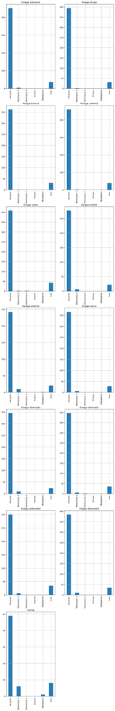

```python
Wykresy_rymow(df)
```

Teraz następuje proces dodawania kolejnych warunków w których różne litery możemy potraktować jako takie które sobie odpowiadają. Po dodaniu tych warunków wyświetlana jest nowa macierz która reprezentuje obecny wynik klasyfikacji, a pod nią przedstawiane są zmiany jakie zaszły w porównaniu z poprzednią wersją.

```python
# Dodając polskie odpowiadające sobie litery

# rz - ż (każe gospodarze)
litery.append(lambda str1,str2,i1,i2,i1m,i2m :(i1 > 0 and str1[i1] == 'z' and str2[i2] == "ż" and str1[i1-1] == 'r',1,0))
litery.append(lambda str1,str2,i1,i2,i1m,i2m :(i2 > 0 and str1[i1] =="ż" and str2[i2] == "z" and str2[i2-1] == 'r',0,1))

# u - ó
litery.append(lambda str1,str2,i1,i2,i1m,i2m :(str1[i1] in ["u", "ó"] and str2[i2] in ["ó", "u"],0,0))
```

```python
zbr = okresl_rymy(PanTadeusz,OkresloneWersy)
df2 = stastyki(zbr)
df2
```

|  | Parzyste | Monorymy 3 | Monorymy 4 | Krzywe | Okalajance | Inne |
| --- | --- | --- | --- | --- | --- | --- |
| Księga pierwsza | 456 | 4 | 0 | 0 | 0 | 31 |
| Księga druga | 397 | 1 | 0 | 0 | 0 | 28 |
| Księga trzecia | 364 | 1 | 0 | 0 | 0 | 29 |
| Księga czwarta | 462 | 2 | 0 | 0 | 0 | 36 |
| Księga piąta | 415 | 1 | 1 | 0 | 0 | 35 |
| Księga szósta | 278 | 6 | 0 | 0 | 0 | 21 |
| Księga siódma | 242 | 10 | 0 | 0 | 1 | 20 |
| Księga ósma | 369 | 7 | 0 | 0 | 0 | 23 |
| Księga dziewiąta | 348 | 9 | 0 | 0 | 0 | 20 |
| Księga dziesiąta | 400 | 5 | 0 | 0 | 0 | 33 |
| Księga jedenasta | 302 | 7 | 0 | 0 | 0 | 30 |
| Księga dwunasta | 388 | 10 | 0 | 0 | 0 | 30 |
| epilog | 51 | 6 | 0 | 0 | 1 | 6 |

```python
df2 - df
```

|  | Parzyste | Monorymy 3 | Monorymy 4 | Krzywe | Okalajance | Inne |
| --- | --- | --- | --- | --- | --- | --- |
| Księga pierwsza | 5 | 0 | 0 | 0 | 0 | -5 |
| Księga druga | 3 | 0 | 0 | 0 | 0 | -3 |
| Księga trzecia | 2 | 0 | 0 | 0 | 0 | -2 |
| Księga czwarta | 2 | 0 | 0 | 0 | 0 | -2 |
| Księga piąta | 7 | 0 | 0 | 0 | 0 | -7 |
| Księga szósta | 1 | 0 | 0 | 0 | 0 | -1 |
| Księga siódma | 0 | 0 | 0 | 0 | 0 | 0 |
| Księga ósma | 4 | 1 | 0 | 0 | 0 | -5 |
| Księga dziewiąta | 3 | 0 | 0 | 0 | 0 | -3 |
| Księga dziesiąta | 4 | 0 | -1 | 0 | 0 | -2 |
| Księga jedenasta | 2 | 1 | 0 | 0 | 0 | -4 |
| Księga dwunasta | 4 | 0 | 0 | 0 | 0 | -4 |
| epilog | 2 | 0 | 0 | 0 | 0 | -2 |

```python
#samogłoski nosową ą - ę
# en - ę (ręce sukience)
litery.append(lambda str1,str2,i1,i2,i1m,i2m :(i1 > 0 and str1[i1] == 'n' and str2[i2] == "ę" and str1[i1-1] == 'e',1,0))
litery.append(lambda str1,str2,i1,i2,i1m,i2m :(i2 > 0 and str1[i1] == "ę" and str2[i2] == "n" and str2[i2-1] == 'e',0,1))

# e - ę (krzyknęli spółobywateli)
litery.append(lambda str1,str2,i1,i2,i1m,i2m :(str1[i1] in ["e", "ę"] and str2[i2] in ["e", "ę"],0,0))

 # on - ą (kabłąki dzwonki)
litery.append(lambda str1,str2,i1,i2,i1m,i2m :(i1 > 0 and str1[i1] == 'n' and str2[i2] == "ą" and str1[i1-1] == 'o',1,0))
litery.append(lambda str1,str2,i1,i2,i1m,i2m :(i2 > 0 and str1[i1] == "ą" and str2[i2] == "n" and str2[i2-1] == 'o',0,1))

#wymiana ą - a / ą - o / o - a (łono utęsknioną)
litery.append(lambda str1,str2,i1,i2,i1m,i2m :(i1 == i1m and str1[i1] in ["ą","o", "a"] and str2[i2] in ["a","o", "ą"],0,0))

litery.append(lambda str1,str2,i1,i2,i1m,i2m :(i1m == i1 and str1[i1] in ["e", "ę"] and str2[i2] in ["e", "ę"],0,0))

# en - eń (sukience wieńce)
litery.append(lambda str1,str2,i1,i2,i1m,i2m :(i1 > 1 and i2 > 1 and str1[i1] == 'n' and str2[i2] == "ń" and str1[i1-1] == 'e' and str2[i2-1] == 'e',1,1))
litery.append(lambda str1,str2,i1,i2,i1m,i2m :(i2 > 0 and i1 > 1 and i2 > 1 and str1[i1] == "ń" and str2[i2] == "n" and str2[i2-1] == 'e' and str1[i1-1] == 'e',1,1))

# ę  - eń (maleńka klęka)
litery.append(lambda str1,str2,i1,i2,i1m,i2m :(i1 > 0 and str1[i1] == 'ń' and str2[i2] == "ę" and str1[i1-1] == 'e',1,0))
litery.append(lambda str1,str2,i1,i2,i1m,i2m :(i2 > 0 and str1[i1] == "ę" and str2[i2] == "ń" and str2[i2-1] == 'e',0,1))
```

```python
zbr = okresl_rymy(PanTadeusz,OkresloneWersy)
df3 = stastyki(zbr)
df3
```

|  | Parzyste | Monorymy 3 | Monorymy 4 | Krzywe | Okalajance | Inne |
| --- | --- | --- | --- | --- | --- | --- |
| Księga pierwsza | 480 | 5 | 0 | 0 | 0 | 5 |
| Księga druga | 420 | 1 | 0 | 0 | 0 | 5 |
| Księga trzecia | 384 | 1 | 0 | 0 | 0 | 9 |
| Księga czwarta | 487 | 2 | 0 | 0 | 0 | 11 |
| Księga piąta | 441 | 2 | 2 | 0 | 0 | 5 |
| Księga szósta | 298 | 6 | 0 | 0 | 0 | 1 |
| Księga siódma | 251 | 11 | 2 | 0 | 0 | 6 |
| Księga ósma | 388 | 7 | 0 | 0 | 0 | 4 |
| Księga dziewiąta | 362 | 9 | 0 | 0 | 0 | 6 |
| Księga dziesiąta | 421 | 5 | 1 | 0 | 0 | 10 |
| Księga jedenasta | 323 | 8 | 0 | 0 | 0 | 8 |
| Księga dwunasta | 406 | 10 | 1 | 0 | 0 | 10 |
| epilog | 51 | 7 | 0 | 0 | 1 | 4 |

```python
df3 - df2
```

|  | Parzyste | Monorymy 3 | Monorymy 4 | Krzywe | Okalajance | Inne |
| --- | --- | --- | --- | --- | --- | --- |
| Księga pierwsza | 24 | 1 | 0 | 0 | 0 | -26 |
| Księga druga | 23 | 0 | 0 | 0 | 0 | -23 |
| Księga trzecia | 20 | 0 | 0 | 0 | 0 | -20 |
| Księga czwarta | 25 | 0 | 0 | 0 | 0 | -25 |
| Księga piąta | 26 | 1 | 1 | 0 | 0 | -30 |
| Księga szósta | 20 | 0 | 0 | 0 | 0 | -20 |
| Księga siódma | 9 | 1 | 2 | 0 | -1 | -14 |
| Księga ósma | 19 | 0 | 0 | 0 | 0 | -19 |
| Księga dziewiąta | 14 | 0 | 0 | 0 | 0 | -14 |
| Księga dziesiąta | 21 | 0 | 1 | 0 | 0 | -23 |
| Księga jedenasta | 21 | 1 | 0 | 0 | 0 | -22 |
| Księga dwunasta | 18 | 0 | 1 | 0 | 0 | -20 |
| epilog | 0 | 1 | 0 | 0 | 0 | -2 |

```python
#kombinacje i - j

# ij  - i (myśli wyślij)
litery.append(lambda str1,str2,i1,i2,i1m,i2m :(i1 > 0 and str1[i1] == 'j' and str2[i2] == "i" and str1[i1-1] == 'i',1,0))
litery.append(lambda str1,str2,i1,i2,i1m,i2m :(i2 > 0 and str1[i1] == "i" and str2[i2] == "j" and str2[i2-1] == 'e',0,1))
```

```python
zbr = okresl_rymy(PanTadeusz,OkresloneWersy)
df4 = stastyki(zbr)
df4
```

|  | Parzyste | Monorymy 3 | Monorymy 4 | Krzywe | Okalajance | Inne |
| --- | --- | --- | --- | --- | --- | --- |
| Księga pierwsza | 480 | 5 | 0 | 0 | 0 | 5 |
| Księga druga | 420 | 1 | 0 | 0 | 0 | 5 |
| Księga trzecia | 385 | 1 | 0 | 0 | 0 | 8 |
| Księga czwarta | 487 | 2 | 0 | 0 | 0 | 11 |
| Księga piąta | 441 | 2 | 2 | 0 | 0 | 5 |
| Księga szósta | 298 | 6 | 0 | 0 | 0 | 1 |
| Księga siódma | 249 | 11 | 3 | 0 | 0 | 6 |
| Księga ósma | 388 | 7 | 0 | 0 | 0 | 4 |
| Księga dziewiąta | 362 | 9 | 0 | 0 | 0 | 6 |
| Księga dziesiąta | 421 | 5 | 1 | 0 | 0 | 10 |
| Księga jedenasta | 323 | 8 | 0 | 0 | 0 | 8 |
| Księga dwunasta | 406 | 10 | 1 | 0 | 0 | 10 |
| epilog | 51 | 7 | 0 | 0 | 1 | 4 |

```python
df4 - df3
```

|  | Parzyste | Monorymy 3 | Monorymy 4 | Krzywe | Okalajance | Inne |
| --- | --- | --- | --- | --- | --- | --- |
| Księga pierwsza | 0 | 0 | 0 | 0 | 0 | 0 |
| Księga druga | 0 | 0 | 0 | 0 | 0 | 0 |
| Księga trzecia | 1 | 0 | 0 | 0 | 0 | -1 |
| Księga czwarta | 0 | 0 | 0 | 0 | 0 | 0 |
| Księga piąta | 0 | 0 | 0 | 0 | 0 | 0 |
| Księga szósta | 0 | 0 | 0 | 0 | 0 | 0 |
| Księga siódma | -2 | 0 | 1 | 0 | 0 | 0 |
| Księga ósma | 0 | 0 | 0 | 0 | 0 | 0 |
| Księga dziewiąta | 0 | 0 | 0 | 0 | 0 | 0 |
| Księga dziesiąta | 0 | 0 | 0 | 0 | 0 | 0 |
| Księga jedenasta | 0 | 0 | 0 | 0 | 0 | 0 |
| Księga dwunasta | 0 | 0 | 0 | 0 | 0 | 0 |
| epilog | 0 | 0 | 0 | 0 | 0 | 0 |

```python
# z gwary
#iéj - i do ropatrzenia
litery.append(lambda str1,str2,i1,i2,i1m,i2m :(i1 > 1 and str1[i1] == 'j' and str2[i2] == "i" and str1[i1-1] == 'é' and str1[i1-2] == 'i',2,0))
litery.append(lambda str1,str2,i1,i2,i1m,i2m :(i2 > 1 and str2[i2] == 'j' and str1[i1] == "i" and str2[i2-1] == 'é' and str2[i2-2] == 'i',0,2))


# éj - y (bliżéj chyży) - GWARA (BLIZŻYJ- CHYŻYj)
litery.append(lambda str1,str2,i1,i2,i1m,i2m :(i1 > 0 and str1[i1] == 'j' and str2[i2] == "y" and str1[i1-1] == 'é',1,0))
litery.append(lambda str1,str2,i1,i2,i1m,i2m :(i2 > 0 and str1[i1] =="y" and str2[i2] == "j" and str2[i2-1] == 'é',0,1))


 # ej - y (pijany wygranej)
litery.append(lambda str1,str2,i1,i2,i1m,i2m :(i1 > 0 and str1[i1] == 'j' and str2[i2] == "y" and str1[i1-1] == 'e',1,0))
litery.append(lambda str1,str2,i1,i2,i1m,i2m :(i2 > 0 and str1[i1] =="y" and str2[i2] == "j" and str2[i2-1] == 'e',0,1))


# éj - i (daléj kichali) - GWARA (DALLi - KICHALI)
litery.append(lambda str1,str2,i1,i2,i1m,i2m :(i1 > 0 and str1[i1] == 'j' and str2[i2] == "i" and str1[i1-1] == 'é',1,0))
litery.append(lambda str1,str2,i1,i2,i1m,i2m :(i2 > 0 and str1[i1] =="i" and str2[i2] == "j" and str2[i2-1] == 'é',0,1))


 # ié - i (lice świéce) - GWARA (LICE - ŚWICE)
litery.append(lambda str1,str2,i1,i2,i1m,i2m :(i1 > 0 and str1[i1] == 'é' and str2[i2] == "i" and str1[i1-1] == 'i',1,0))
litery.append(lambda str1,str2,i1,i2,i1m,i2m :(i2 > 0 and str1[i1] =="i" and str2[i2] == "é" and str2[i2-1] == 'i',0,1))

# é - y (przewietrzyć przetrzéć)
litery.append(lambda str1,str2,i1,i2,i1m,i2m :(str1[i1] in ["é", "y"] and str2[i2] in ["é", "y"],0,0))


# e - y (ogonem szalonym)
litery.append(lambda str1,str2,i1,i2,i1m,i2m :(str1[i1] in ["e", "y"] and str2[i2] in ["e", "y"],0,0))
```

```python
zbr = okresl_rymy(PanTadeusz,OkresloneWersy)
df5 = stastyki(zbr)
df5
```

|  | Parzyste | Monorymy 3 | Monorymy 4 | Krzywe | Okalajance | Inne |
| --- | --- | --- | --- | --- | --- | --- |
| Księga pierwsza | 485 | 5 | 0 | 0 | 0 | 0 |
| Księga druga | 425 | 1 | 0 | 0 | 0 | 0 |
| Księga trzecia | 391 | 1 | 0 | 0 | 0 | 2 |
| Księga czwarta | 496 | 2 | 0 | 0 | 0 | 2 |
| Księga piąta | 443 | 2 | 2 | 0 | 0 | 3 |
| Księga szósta | 299 | 6 | 0 | 0 | 0 | 0 |
| Księga siódma | 251 | 11 | 3 | 0 | 0 | 4 |
| Księga ósma | 390 | 7 | 0 | 0 | 0 | 2 |
| Księga dziewiąta | 366 | 9 | 0 | 0 | 0 | 2 |
| Księga dziesiąta | 424 | 5 | 1 | 0 | 0 | 7 |
| Księga jedenasta | 324 | 9 | 0 | 0 | 0 | 5 |
| Księga dwunasta | 410 | 11 | 1 | 0 | 0 | 3 |
| epilog | 51 | 7 | 0 | 0 | 1 | 4 |

```python
df5 - df4
```

|  | Parzyste | Monorymy 3 | Monorymy 4 | Krzywe | Okalajance | Inne |
| --- | --- | --- | --- | --- | --- | --- |
| Księga pierwsza | 5 | 0 | 0 | 0 | 0 | -5 |
| Księga druga | 5 | 0 | 0 | 0 | 0 | -5 |
| Księga trzecia | 6 | 0 | 0 | 0 | 0 | -6 |
| Księga czwarta | 9 | 0 | 0 | 0 | 0 | -9 |
| Księga piąta | 2 | 0 | 0 | 0 | 0 | -2 |
| Księga szósta | 1 | 0 | 0 | 0 | 0 | -1 |
| Księga siódma | 2 | 0 | 0 | 0 | 0 | -2 |
| Księga ósma | 2 | 0 | 0 | 0 | 0 | -2 |
| Księga dziewiąta | 4 | 0 | 0 | 0 | 0 | -4 |
| Księga dziesiąta | 3 | 0 | 0 | 0 | 0 | -3 |
| Księga jedenasta | 1 | 1 | 0 | 0 | 0 | -3 |
| Księga dwunasta | 4 | 1 | 0 | 0 | 0 | -7 |
| epilog | 0 | 0 | 0 | 0 | 0 | 0 |

```python
# y - i (dobrzyna rodzina)
litery.append(lambda str1,str2,i1,i2,i1m,i2m :(i1 != i1m and str1[i1] in ["y", "i"] and str2[i2] in ["y", "i"],0,0))

# ź - ś (groźby prośby)
litery.append(lambda str1,str2,i1,i2,i1m,i2m :(str1[i1] in ["ź", "ś"] and str2[i2] in ["ź", "ś"],0,0))


 # z - s (wózku francusku)
litery.append(lambda str1,str2,i1,i2,i1m,i2m :(str1[i1] in ["z", "s"] and str2[i2] in ["z", "s"],0,0))


# o - ó (odmówi starcowi)
litery.append(lambda str1,str2,i1,i2,i1m,i2m :(str1[i1] in ["o", "ó"] and str2[i2] in ["o", "ó"],0,0))


# z - ż (francuza duża)
litery.append(lambda str1,str2,i1,i2,i1m,i2m :(str1[i1] in ["z", "ż"] and str2[i2] in ["z", "ż"],0,0))

 # lt - l (kolei - amaltei)
litery.append(lambda str1,str2,i1,i2,i1m,i2m :(i1 > 0 and str1[i1] == 't' and str2[i2] == "l" and str1[i1-1] == 'l',1,0))
litery.append(lambda str1,str2,i1,i2,i1m,i2m :(i2 > 0 and str1[i1] =="l" and str2[i2] == "t" and str2[i2-1] == 'l',0,1))

 # dz - n (nadziei - kniei)
litery.append(lambda str1,str2,i1,i2,i1m,i2m :(i1 > 0 and str1[i1] == 'z' and str2[i2] == "n" and str1[i1-1] == 'd',1,0))
litery.append(lambda str1,str2,i1,i2,i1m,i2m :(i2 > 0 and str1[i1] =="n" and str2[i2] == "z" and str2[i2-1] == 'd',0,1))

 # łł - ł (zdziwił - radziwiłł)
litery.append(lambda str1,str2,i1,i2,i1m,i2m :(i1 != i1m and str1[i1] == 'ł' and str2[i2 + 1] == "ł" and str1[i1 +1] == 'ł',0,-1))
litery.append(lambda str1,str2,i1,i2,i1m,i2m :(i2 != i2m and str1[i1] =="ł" and str2[i2 +1] == "ł" and str2[i2 + 1] == 'ł',-1,0))
```

```python
zbr = okresl_rymy(PanTadeusz,OkresloneWersy)
df6 = stastyki(zbr)
df6
```

|  | Parzyste | Monorymy 3 | Monorymy 4 | Krzywe | Okalajance | Inne |
| --- | --- | --- | --- | --- | --- | --- |
| Księga pierwsza | 485 | 5 | 0 | 0 | 0 | 0 |
| Księga druga | 423 | 1 | 1 | 0 | 0 | 0 |
| Księga trzecia | 390 | 1 | 1 | 0 | 0 | 1 |
| Księga czwarta | 497 | 2 | 0 | 0 | 0 | 1 |
| Księga piąta | 443 | 2 | 2 | 0 | 0 | 3 |
| Księga szósta | 299 | 6 | 0 | 0 | 0 | 0 |
| Księga siódma | 251 | 12 | 3 | 0 | 0 | 2 |
| Księga ósma | 391 | 7 | 0 | 0 | 0 | 1 |
| Księga dziewiąta | 365 | 10 | 0 | 0 | 0 | 1 |
| Księga dziesiąta | 425 | 5 | 1 | 0 | 0 | 6 |
| Księga jedenasta | 322 | 12 | 0 | 0 | 0 | 1 |
| Księga dwunasta | 410 | 11 | 1 | 0 | 0 | 3 |
| epilog | 51 | 7 | 0 | 0 | 1 | 4 |

```python
df6-df5
```

|  | Parzyste | Monorymy 3 | Monorymy 4 | Krzywe | Okalajance | Inne |
| --- | --- | --- | --- | --- | --- | --- |
| Księga pierwsza | 0 | 0 | 0 | 0 | 0 | 0 |
| Księga druga | -2 | 0 | 1 | 0 | 0 | 0 |
| Księga trzecia | -1 | 0 | 1 | 0 | 0 | -1 |
| Księga czwarta | 1 | 0 | 0 | 0 | 0 | -1 |
| Księga piąta | 0 | 0 | 0 | 0 | 0 | 0 |
| Księga szósta | 0 | 0 | 0 | 0 | 0 | 0 |
| Księga siódma | 0 | 1 | 0 | 0 | 0 | -2 |
| Księga ósma | 1 | 0 | 0 | 0 | 0 | -1 |
| Księga dziewiąta | -1 | 1 | 0 | 0 | 0 | -1 |
| Księga dziesiąta | 1 | 0 | 0 | 0 | 0 | -1 |
| Księga jedenasta | -2 | 3 | 0 | 0 | 0 | -4 |
| Księga dwunasta | 0 | 0 | 0 | 0 | 0 | 0 |
| epilog | 0 | 0 | 0 | 0 | 0 | 0 |

Po dodaniu wszystkich warunków wynik jaki udało się osiągnąć ma się następująco. Niemalże wszystkie wersy udało się sklasyfikować, pozostało średnio dwa wersy na księgę nie zostały sklasyfikowane, wynika to ze specyficznej budowy "Pana Tadeusza", Adam Mickiewicz w celu utrzymania spójności rymów i formę (trzynastozgłoskowiec) rozkładał niektóre wersy na dwie linie, co było problematyczne w uchwyceniu.

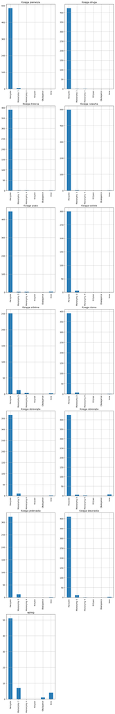

```python
Wykresy_rymow(stastyki(zbr))
```

```python
#Pozostałe nie skalsywikoane rymy
#Pojedyncze nie mają zgodności z sąsiadami
#Podwójne nie udało się połączyć między sobą
for i in range(13):
    print(zbr[i]["inne"])
```

```
[]
[]
['szerokim obłokiem']
['bojaźni najwyraźniej']
['rozmawiali', 'uchu muchą', 'nogą trwogę']
[]
['pańskim', 'sakiem takim']
['zaciął przyjaciół']
['katy stuknie']
['scyzorykiem nikim', 'działo', 'zaczepkę', 'kraju', 'zosię', 'uzbroi moi']
['czwartą']
['stoi boi', 'zmaca', 'nadziei kolei']
['krainie', 'przebrzmiała', 'przyszłości', 'sławie']
```

Funkcja wypisz_wersy wypisuje odpowiednie wersy zaznaczając kolorem jaka część wyrazu się ze sobą rymuje oraz dopisuje jaki rodzaj rymu to jest. Argumenty funkcji to odpowiednio zbiór sklasyfikowanych wersów, Rozpatrywania księga indeksowana od 0, wers początkowy oraz wers kończący (-1 odpowiada ostatniemu wersowi) Rodzaje rymów są oznaczone w następujący sposób monorymy P - parzyste rymy M - monorymy o długości 3 lub 4 K - rymy krzywe O - rymy okalające I - inne nieudana klasyfikacja Poniżej są przykłady jak prezentują się poszczególne fragmenty różnych ksiąg.

```python
wypisz_wersy(OkresloneWersy,6,115,125)
```

```
poznałem co za ptaszek ksiądz oczy odwrócił P
lękając się żebym go nie zaczął spowiadać P
ale to rzecz nie moja wiele o tym gadać P
on tu nie przyjdzie próżno wzywać bernardyna M
jeśli od niego wyszła ta cała nowina M
to kto wie w jakim celu bo to bies księżyna M
jeśli prócz tej nowiny nic więcej nie wiecie P
więc po coście tu przyszli i czego wy chcecie P
wojny krzyknęli jakiej spytał zawołali P
wojny z moskalem bić się hejże na moskali P
```

```python
wypisz_wersy(OkresloneWersy,2,600,610)
```

```
prawdziwie będą z pana żartować sąsiedzi P
że mieszkając na żyznej litewskiej równinie M
malujesz tylko jakieś skały i pustynie M
przyjacielu rzekł hrabia piękne przyrodzenie M
jest formą tłem materią a duszą natchnienie M
które na wyobraźni unosi się skrzydłach P
poleruje się gustem wspiera na prawidłach P
nie dość jest przyrodzenia nie dosyć zapału P
sztukmistrz musi ulecieć w sfery ideału P
nie wszystko co jest piękne wymalować da się P
```

```python
wypisz_wersy(OkresloneWersy,0,0,20)
```

```
litwo ojczyzno moja ty jesteś jak zdrowie P
ile cię trzeba cenić ten tylko się dowie P
kto cię stracił dziś piękność twą w całej ozdobie P
widzę i opisuję bo tęsknię po tobie P
panno święta co jasnej bronisz częstochowy P
i w ostrej świecisz bramie ty co gród zamkowy P
nowogródzki ochraniasz z jego wiernym ludem P
jak mnie dziecko do zdrowia powróciłaś cudem P
gdy od płaczącej matki pod twoją opiekę P
ofiarowany martwą podniosłem powiekę P
i zaraz mogłem pieszo do twych świątyń progu P
iść za wrócone życie podziękować bogu P
tak nas powrócisz cudem na ojczyzny łono P
tymczasem przenoś moją duszę utęsknioną P
do tych pagórków leśnych do tych łąk zielonych P
szeroko nad błękitnym niemnem rozciągnionych P
do tych pól malowanych zbożem rozmaitem P
wyzłacanych pszenicą posrebrzanych żytem P
gdzie bursztynowy świerzop gryka jak śnieg biała P
gdzie panieńskim rumieńcem dzięcielina pała P
```

```python
wypisz_wersy(OkresloneWersy,12,55,67)
```

```
umilknie światu swobodę obwieści P
wtenczas dębowym liściem uwieńczeni P
rzuciwszy miecze siędą rozbrojeni P
rycerze nasi zechcą słuchać o przeszłości O
wtenczas zapłaczą nad ojców losami O
i wtenczas łza ta ich lica nie splami O
dziś dla nas w świecie nieproszonych gości O
w całej przeszłości i w całej przyszłości I
jedna już tylko dziś kraina taka P
w której jest trochę szczęścia dla polaka P
kraj lat dziecinnych on zawsze zostanie P
święty i czysty jak pierwsze kochanie P
```

Teraza jest wykonywana jest próba rozrurznienia ksiąg na podstawie rymujących się końcówek.

```python
#Wyądrebnienie rymujących się końcówek z rymów
tokeny_rymy = []
for pzbr in zbr:
    lista_slow = []
    for m2 in pzbr["monorymy"][2]:
        lista_slow.append(m2[0])
        lista_slow.append(m2[1])
    for m3 in pzbr["monorymy"][3]:
        lista_slow.append(rymy_koncowe(m3[0],m3[1])[0])
        lista_slow.append(rymy_koncowe(m3[0],m3[1])[1])
        lista_slow.append(rymy_koncowe(m3[1],m3[2])[0])
    for m4 in pzbr["monorymy"][4]:
        lista_slow.append(m4[0])
        lista_slow.append(m4[0])
        lista_slow.append(m4[1])
        lista_slow.append(m4[1])
    tokeny_rymy.append(lista_slow)
```

```python
#Łączenie tabel rymów poszczególnych ksiąg w jedną
tokeny_calosc = []
for i in tokeny_rymy:
    tokeny_calosc += i
```

```python
#Tworzenie słownika
slownikPT = utworz_slownik(tokeny_calosc)
```

```python
#Sortowanie słownika
slownikPT2 = dict(sorted(slownikPT.items(), key=lambda x: x[1], reverse = True))
```

Z końcówek został zrobiony słownik który pokazuje ile razy każda z końcówke wystapiła w tekscie.

```python
pokaz_czeste(slownikPT2,30)
```

```
anie : 90
ali : 84
owy : 82
ony : 75
owie : 71
ana : 66
any : 63
awy : 62
ami : 60
ania : 58
azy : 51
ały : 50
ada : 48
ona : 48
ody : 46
oru : 44
aty : 41
ował : 41
osi : 40
ady : 38
ele : 38
ata : 37
ało : 37
enie : 37
icy : 37
aczy : 36
obie : 36
odu : 36
ole : 36
owa : 36
ica : 35
odzi : 35
okiem : 35
ury : 35
usza : 35
ary : 34
omu : 34
ości : 33
odził : 32
ogi : 32
ety : 31
```

Mając słownik możemy wyliczyć miary takie jak tf czy tf-idf.

```python
# Miara tf (term frequency) dla końcówek w poszczególnych księgach
tdm = tdmPT(slownikPT2,30)
tdm
```

|  | K1 | K2 | K3 | K4 | K5 | K6 | K7 | K8 | K9 | K10 | K11 | K12 | Epilog |
| --- | --- | --- | --- | --- | --- | --- | --- | --- | --- | --- | --- | --- | --- |
| anie | 12 | 13 | 4 | 12 | 4 | 8 | 0 | 8 | 4 | 8 | 4 | 11 | 2 |
| ali | 7 | 16 | 2 | 7 | 8 | 2 | 8 | 1 | 18 | 4 | 4 | 7 | 0 |
| owy | 11 | 10 | 8 | 8 | 10 | 0 | 0 | 2 | 4 | 9 | 10 | 8 | 2 |
| ony | 4 | 6 | 14 | 8 | 4 | 10 | 8 | 0 | 6 | 10 | 3 | 2 | 0 |
| owie | 4 | 2 | 0 | 8 | 4 | 4 | 4 | 7 | 10 | 10 | 7 | 8 | 3 |
| ana | 10 | 8 | 6 | 0 | 4 | 4 | 4 | 8 | 2 | 10 | 6 | 4 | 0 |
| any | 2 | 4 | 4 | 6 | 2 | 4 | 2 | 2 | 7 | 4 | 10 | 16 | 0 |
| awy | 8 | 4 | 8 | 6 | 8 | 0 | 4 | 10 | 0 | 4 | 2 | 8 | 0 |
| ami | 6 | 8 | 0 | 10 | 2 | 4 | 12 | 4 | 2 | 6 | 4 | 2 | 0 |
| ania | 6 | 8 | 10 | 4 | 10 | 0 | 6 | 4 | 2 | 0 | 4 | 4 | 0 |
| azy | 0 | 4 | 0 | 4 | 8 | 0 | 4 | 2 | 12 | 6 | 7 | 4 | 0 |
| ały | 4 | 2 | 4 | 4 | 6 | 2 | 2 | 4 | 3 | 5 | 9 | 5 | 0 |
| ada | 4 | 0 | 2 | 4 | 12 | 2 | 8 | 4 | 8 | 2 | 0 | 2 | 0 |
| ona | 2 | 4 | 6 | 6 | 6 | 7 | 2 | 2 | 0 | 4 | 4 | 5 | 0 |
| ody | 6 | 2 | 4 | 2 | 4 | 4 | 0 | 4 | 8 | 2 | 2 | 6 | 2 |
| oru | 8 | 10 | 0 | 4 | 4 | 0 | 0 | 10 | 6 | 0 | 0 | 2 | 0 |
| aty | 10 | 4 | 6 | 0 | 0 | 2 | 0 | 0 | 2 | 7 | 8 | 2 | 0 |
| ował | 10 | 4 | 2 | 2 | 8 | 0 | 0 | 4 | 0 | 6 | 1 | 4 | 0 |
| osi | 0 | 0 | 2 | 4 | 6 | 2 | 0 | 6 | 4 | 4 | 2 | 10 | 0 |
| ady | 0 | 4 | 0 | 2 | 2 | 12 | 0 | 2 | 4 | 6 | 0 | 6 | 0 |
| ele | 2 | 1 | 0 | 1 | 3 | 3 | 2 | 8 | 8 | 4 | 0 | 4 | 2 |
| ata | 2 | 0 | 6 | 0 | 2 | 2 | 6 | 2 | 2 | 4 | 7 | 4 | 0 |
| ało | 10 | 2 | 0 | 13 | 2 | 3 | 1 | 0 | 0 | 4 | 0 | 1 | 1 |
| enie | 0 | 2 | 2 | 8 | 6 | 0 | 0 | 6 | 0 | 4 | 4 | 5 | 0 |
| icy | 0 | 0 | 6 | 7 | 6 | 3 | 2 | 0 | 1 | 2 | 6 | 2 | 2 |
| aczy | 3 | 6 | 4 | 2 | 6 | 4 | 0 | 2 | 0 | 6 | 0 | 3 | 0 |
| obie | 8 | 5 | 2 | 0 | 1 | 0 | 2 | 2 | 2 | 5 | 2 | 4 | 3 |
| odu | 0 | 2 | 4 | 6 | 0 | 10 | 0 | 0 | 8 | 0 | 4 | 2 | 0 |
| ole | 8 | 1 | 1 | 3 | 2 | 1 | 1 | 3 | 7 | 2 | 6 | 1 | 0 |
| owa | 4 | 4 | 2 | 4 | 2 | 2 | 4 | 0 | 6 | 0 | 2 | 6 | 0 |
| ica | 2 | 4 | 2 | 6 | 2 | 2 | 2 | 4 | 0 | 2 | 5 | 4 | 0 |
| odzi | 4 | 0 | 8 | 2 | 4 | 0 | 3 | 4 | 0 | 4 | 2 | 4 | 0 |
| okiem | 2 | 8 | 6 | 5 | 6 | 2 | 2 | 2 | 2 | 0 | 0 | 0 | 0 |
| ury | 2 | 5 | 2 | 5 | 5 | 4 | 2 | 1 | 3 | 1 | 2 | 3 | 0 |
| usza | 4 | 0 | 6 | 4 | 4 | 0 | 2 | 3 | 2 | 4 | 0 | 6 | 0 |
| ary | 4 | 4 | 0 | 6 | 6 | 0 | 2 | 2 | 2 | 4 | 0 | 4 | 0 |
| omu | 8 | 0 | 2 | 6 | 8 | 2 | 2 | 0 | 0 | 2 | 4 | 0 | 0 |
| ości | 8 | 0 | 3 | 8 | 6 | 0 | 0 | 2 | 0 | 0 | 2 | 4 | 0 |
| odził | 4 | 4 | 0 | 4 | 0 | 2 | 4 | 5 | 2 | 2 | 0 | 5 | 0 |
| ogi | 6 | 2 | 0 | 8 | 2 | 0 | 2 | 0 | 4 | 4 | 2 | 2 | 0 |
| ety | 4 | 0 | 2 | 4 | 6 | 2 | 2 | 0 | 7 | 0 | 2 | 2 | 0 |

```python
# miara tf-idf gdzie idf (inverted document frequency) to odwrotność liczby dokumentów w
# których wystąpiło dane słowo do liczby wszystkich dokumentów
# tf-idf iloczyn miar tf i idf pozwalający określić unikalność słów
tfidf = policz_tfidf(tdm)
tfidf
```

|  | K1 | K2 | K3 | K4 | K5 | K6 | K7 | K8 | K9 | K10 | K11 | K12 | Epilog | w_ilu | idf |
| --- | --- | --- | --- | --- | --- | --- | --- | --- | --- | --- | --- | --- | --- | --- | --- |
| anie | 0.483 | 0.638 | 0.229 | 0.473 | 0.168 | 0.587 | 0.000 | 0.493 | 0.203 | 0.398 | 0.234 | 0.484 | 0.942 | 12 | 0.080 |
| ali | 0.282 | 0.786 | 0.114 | 0.276 | 0.335 | 0.147 | 0.610 | 0.062 | 0.912 | 0.199 | 0.234 | 0.308 | 0.000 | 12 | 0.080 |
| owy | 0.923 | 1.025 | 0.955 | 0.658 | 0.875 | 0.000 | 0.000 | 0.257 | 0.423 | 0.934 | 1.219 | 0.734 | 1.965 | 11 | 0.167 |
| ony | 0.336 | 0.615 | 1.671 | 0.658 | 0.350 | 1.533 | 1.273 | 0.000 | 0.634 | 1.038 | 0.366 | 0.184 | 0.000 | 11 | 0.167 |
| owie | 0.161 | 0.098 | 0.000 | 0.315 | 0.168 | 0.294 | 0.305 | 0.431 | 0.507 | 0.497 | 0.409 | 0.352 | 1.413 | 12 | 0.080 |
| ana | 0.839 | 0.820 | 0.716 | 0.000 | 0.350 | 0.613 | 0.636 | 1.028 | 0.211 | 1.038 | 0.732 | 0.367 | 0.000 | 11 | 0.167 |
| any | 0.080 | 0.196 | 0.229 | 0.237 | 0.084 | 0.294 | 0.152 | 0.123 | 0.355 | 0.199 | 0.584 | 0.704 | 0.000 | 12 | 0.080 |
| awy | 1.055 | 0.644 | 1.499 | 0.775 | 1.099 | 0.000 | 0.999 | 2.018 | 0.000 | 0.652 | 0.383 | 1.153 | 0.000 | 10 | 0.262 |
| ami | 0.504 | 0.820 | 0.000 | 0.823 | 0.175 | 0.613 | 1.909 | 0.514 | 0.211 | 0.623 | 0.488 | 0.184 | 0.000 | 11 | 0.167 |
| ania | 0.791 | 1.288 | 1.874 | 0.517 | 1.374 | 0.000 | 1.499 | 0.807 | 0.332 | 0.000 | 0.766 | 0.577 | 0.000 | 10 | 0.262 |
| azy | 0.000 | 0.902 | 0.000 | 0.725 | 1.540 | 0.000 | 1.401 | 0.566 | 2.793 | 1.370 | 1.879 | 0.808 | 0.000 | 9 | 0.368 |
| ały | 0.161 | 0.098 | 0.229 | 0.158 | 0.251 | 0.147 | 0.152 | 0.246 | 0.152 | 0.249 | 0.526 | 0.220 | 0.000 | 12 | 0.080 |
| ada | 0.527 | 0.000 | 0.375 | 0.517 | 1.648 | 0.481 | 1.999 | 0.807 | 1.328 | 0.326 | 0.000 | 0.288 | 0.000 | 10 | 0.262 |
| ona | 0.168 | 0.410 | 0.716 | 0.494 | 0.525 | 1.073 | 0.318 | 0.257 | 0.000 | 0.415 | 0.488 | 0.459 | 0.000 | 11 | 0.167 |
| ody | 0.241 | 0.098 | 0.229 | 0.079 | 0.168 | 0.294 | 0.000 | 0.246 | 0.405 | 0.099 | 0.117 | 0.264 | 0.942 | 12 | 0.080 |
| oru | 2.489 | 3.798 | 0.000 | 1.220 | 1.296 | 0.000 | 0.000 | 4.762 | 2.351 | 0.000 | 0.000 | 0.680 | 0.000 | 7 | 0.619 |
| aty | 2.440 | 1.191 | 2.081 | 0.000 | 0.000 | 0.891 | 0.000 | 0.000 | 0.615 | 2.111 | 2.835 | 0.534 | 0.000 | 8 | 0.486 |
| ował | 1.848 | 0.902 | 0.525 | 0.362 | 1.540 | 0.000 | 0.000 | 1.131 | 0.000 | 1.370 | 0.268 | 0.808 | 0.000 | 9 | 0.368 |
| osi | 0.000 | 0.000 | 0.525 | 0.725 | 1.155 | 0.675 | 0.000 | 1.697 | 0.931 | 0.914 | 0.537 | 2.020 | 0.000 | 9 | 0.368 |
| ady | 0.000 | 1.191 | 0.000 | 0.478 | 0.508 | 5.345 | 0.000 | 0.747 | 1.229 | 1.809 | 0.000 | 1.601 | 0.000 | 8 | 0.486 |
| ele | 0.168 | 0.102 | 0.000 | 0.082 | 0.262 | 0.460 | 0.318 | 1.028 | 0.846 | 0.415 | 0.000 | 0.367 | 1.965 | 11 | 0.167 |
| ata | 0.264 | 0.000 | 1.124 | 0.000 | 0.275 | 0.481 | 1.499 | 0.404 | 0.332 | 0.652 | 1.341 | 0.577 | 0.000 | 10 | 0.262 |
| ało | 1.848 | 0.451 | 0.000 | 2.355 | 0.385 | 1.012 | 0.350 | 0.000 | 0.000 | 0.914 | 0.000 | 0.202 | 2.163 | 9 | 0.368 |
| enie | 0.000 | 0.596 | 0.694 | 1.913 | 1.525 | 0.000 | 0.000 | 2.241 | 0.000 | 1.206 | 1.418 | 1.334 | 0.000 | 8 | 0.486 |
| icy | 0.000 | 0.000 | 1.124 | 0.905 | 0.824 | 0.722 | 0.500 | 0.000 | 0.166 | 0.326 | 1.149 | 0.288 | 3.087 | 10 | 0.262 |
| aczy | 0.554 | 1.354 | 1.051 | 0.362 | 1.155 | 1.349 | 0.000 | 0.566 | 0.000 | 1.370 | 0.000 | 0.606 | 0.000 | 9 | 0.368 |
| obie | 0.672 | 0.512 | 0.239 | 0.000 | 0.087 | 0.000 | 0.318 | 0.257 | 0.211 | 0.519 | 0.244 | 0.367 | 2.948 | 11 | 0.167 |
| odu | 0.000 | 0.760 | 1.769 | 1.830 | 0.000 | 5.679 | 0.000 | 0.000 | 3.134 | 0.000 | 1.807 | 0.680 | 0.000 | 7 | 0.619 |
| ole | 0.322 | 0.049 | 0.057 | 0.118 | 0.084 | 0.073 | 0.076 | 0.185 | 0.355 | 0.099 | 0.351 | 0.044 | 0.000 | 12 | 0.080 |
| owa | 0.527 | 0.644 | 0.375 | 0.517 | 0.275 | 0.481 | 0.999 | 0.000 | 0.996 | 0.000 | 0.383 | 0.865 | 0.000 | 10 | 0.262 |
| ica | 0.168 | 0.410 | 0.239 | 0.494 | 0.175 | 0.307 | 0.318 | 0.514 | 0.000 | 0.208 | 0.610 | 0.367 | 0.000 | 11 | 0.167 |
| odzi | 0.739 | 0.000 | 2.101 | 0.362 | 0.770 | 0.000 | 1.051 | 1.131 | 0.000 | 0.914 | 0.537 | 0.808 | 0.000 | 9 | 0.368 |
| okiem | 0.370 | 1.805 | 1.576 | 0.906 | 1.155 | 0.675 | 0.700 | 0.566 | 0.465 | 0.000 | 0.000 | 0.000 | 0.000 | 9 | 0.368 |
| ury | 0.080 | 0.246 | 0.114 | 0.197 | 0.210 | 0.294 | 0.152 | 0.062 | 0.152 | 0.050 | 0.117 | 0.132 | 0.000 | 12 | 0.080 |
| usza | 0.739 | 0.000 | 1.576 | 0.725 | 0.770 | 0.000 | 0.700 | 0.849 | 0.465 | 0.914 | 0.000 | 1.212 | 0.000 | 9 | 0.368 |
| ary | 0.739 | 0.902 | 0.000 | 1.087 | 1.155 | 0.000 | 0.700 | 0.566 | 0.465 | 0.914 | 0.000 | 0.808 | 0.000 | 9 | 0.368 |
| omu | 1.952 | 0.000 | 0.694 | 1.435 | 2.034 | 0.891 | 0.925 | 0.000 | 0.000 | 0.603 | 1.418 | 0.000 | 0.000 | 8 | 0.486 |
| ości | 2.489 | 0.000 | 1.327 | 2.440 | 1.945 | 0.000 | 0.000 | 0.952 | 0.000 | 0.000 | 0.904 | 1.361 | 0.000 | 7 | 0.619 |
| odził | 0.739 | 0.902 | 0.000 | 0.725 | 0.000 | 0.675 | 1.401 | 1.414 | 0.465 | 0.457 | 0.000 | 1.010 | 0.000 | 9 | 0.368 |
| ogi | 1.109 | 0.451 | 0.000 | 1.449 | 0.385 | 0.000 | 0.700 | 0.000 | 0.931 | 0.914 | 0.537 | 0.404 | 0.000 | 9 | 0.368 |
| ety | 0.739 | 0.000 | 0.525 | 0.725 | 1.155 | 0.675 | 0.700 | 0.000 | 1.629 | 0.000 | 0.537 | 0.404 | 0.000 | 9 | 0.368 |

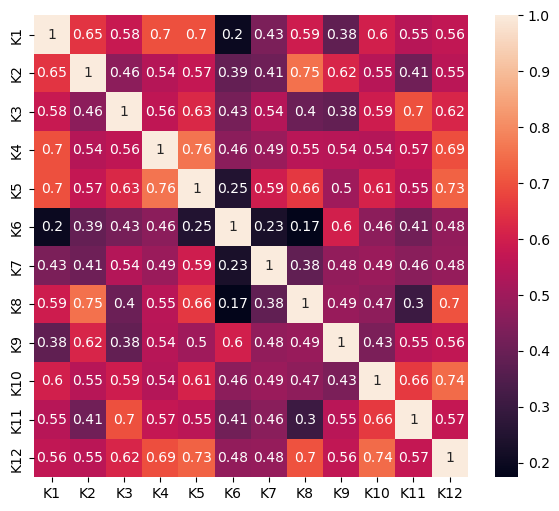

```python
czestosc_odciecia = 30
tdm = tdmPT(slownikPT2,czestosc_odciecia)
tfidf = policz_tfidf(tdm)
mac_odl = np.empty([12,12])
for i in range(0,12):
    for j in range(0,12):
        mac_odl[i,j] = odleglosc(tfidf.iloc[:,i],tfidf.iloc[:,j])
hdf = pd.DataFrame(data=mac_odl,index="K1 K2 K3 K4 K5 K6 K7 K8 K9 K10 K11 K12".split(), columns="K1 K2 K3 K4 K5 K6 K7 K8 K9 K10 K11 K12".split())

plt.figure(figsize=(7,6),dpi = 100)
sns.heatmap(hdf,annot = hdf)
```

Przedstawienie każdej księgi w postaci pasków gdzie każdy kolor reprezentuje występowanie konkretnego rymu, im pasek jest dłuższy tym rym występował częściej.

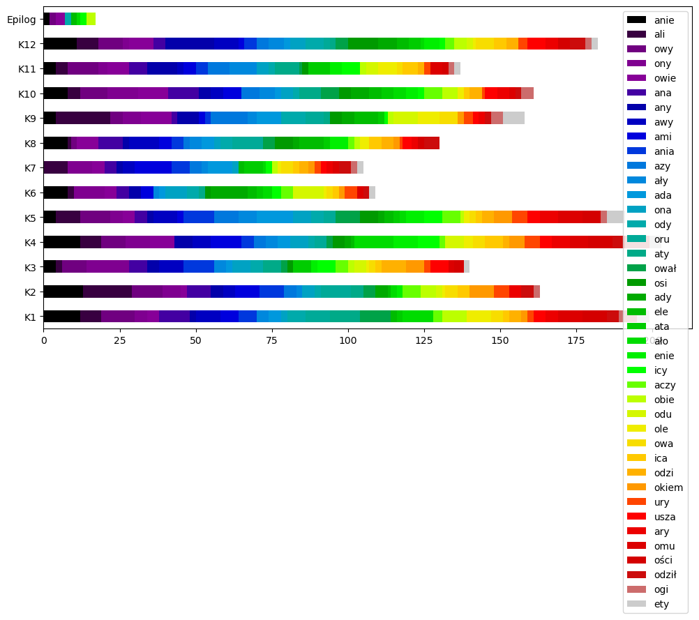

```python
tdm.T.plot.barh(stacked=True,colormap="nipy_spectral",figsize=(12,6))
```

```python
# Przeliczenie aby paski były równej długości
ustandaryzowane = tdm.T.copy()
for i in range(13):
    suma = 0
    for k in ustandaryzowane.iloc[i]:
        suma += k
    for j in range(len(ustandaryzowane.iloc[i])):
        ustandaryzowane.iloc[i,j] = ustandaryzowane.iloc[i,j]/suma
```

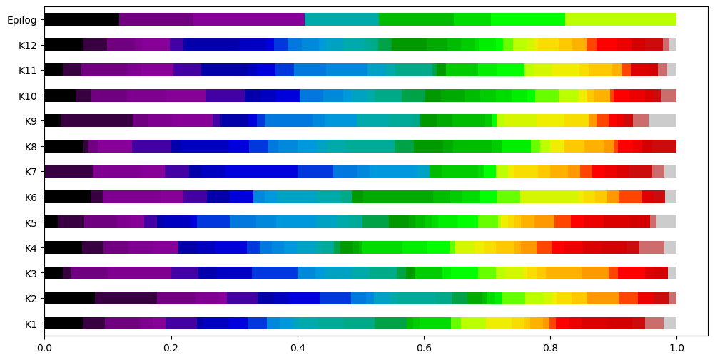

```python
ustandaryzowane.plot.barh(stacked=True,colormap="nipy_spectral",legend=False,figsize=(12,6))
```

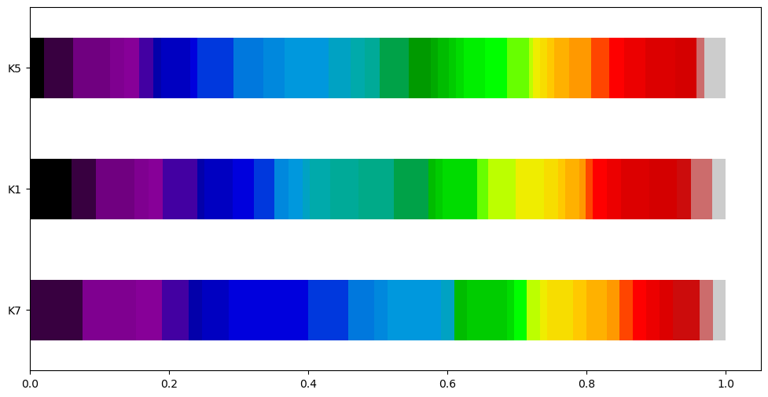

```python
ustandaryzowane.iloc[[6,0,4]].plot.barh(stacked=True,colormap="nipy_spectral",legend=False,figsize=(12,6))
```

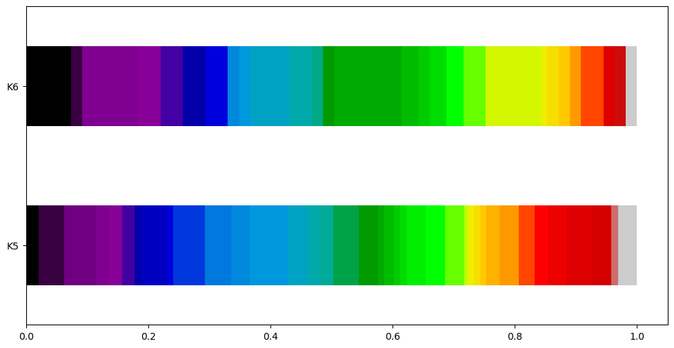

```python
ustandaryzowane.iloc[[4,5]].plot.barh(stacked=True,colormap="nipy_spectral",legend=False,figsize=(12,6))
```

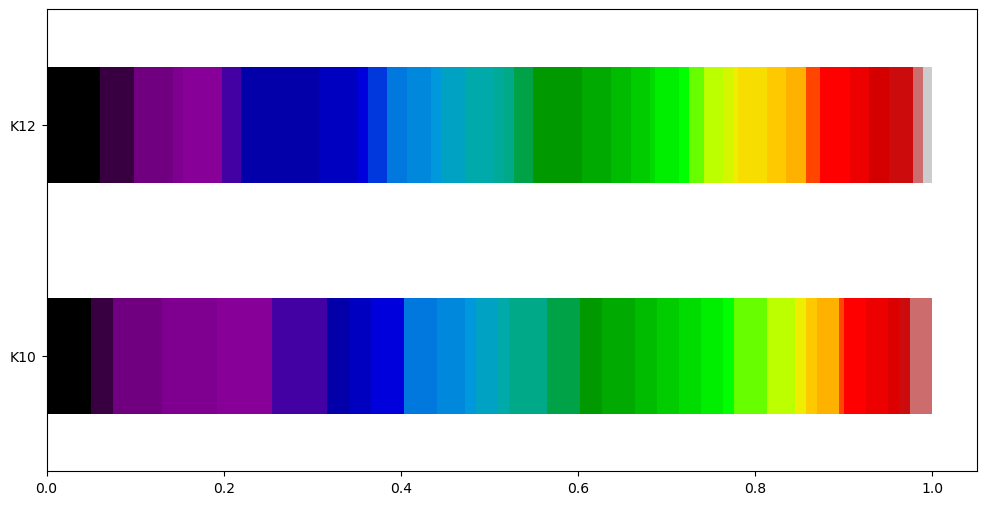

```python
ustandaryzowane.iloc[[9,11]].plot.barh(stacked=True,colormap="nipy_spectral",legend=False,figsize=(12,6))
```